# Topic 1 Exercises

## Question 2.4.9

```r
#download.file("http://www-bcf.usc.edu/~gareth/ISL/Auto.csv", destfile = "Auto.csv")
Auto <- read.csv("/home/local/MAC/dluc/Math-253-Assignment/Auto.csv", na.strings = "?")
Auto <- na.omit(Auto)
summary(Auto)
```

```
##       mpg          cylinders      displacement     horsepower
##  Min.   : 9.00   Min.   :3.000   Min.   : 68.0   Min.   : 46.0
##  1st Qu.:17.00   1st Qu.:4.000   1st Qu.:105.0   1st Qu.: 75.0
##  Median :22.75   Median :4.000   Median :151.0   Median : 93.5
##  Mean   :23.45   Mean   :5.472   Mean   :194.4   Mean   :104.5
##  3rd Qu.:29.00   3rd Qu.:8.000   3rd Qu.:275.8   3rd Qu.:126.0
##  Max.   :46.60   Max.   :8.000   Max.   :455.0   Max.   :230.0
##
##      weight      acceleration        year           origin
##  Min.   :1613   Min.   : 8.00   Min.   :70.00   Min.   :1.000
##  1st Qu.:2225   1st Qu.:13.78   1st Qu.:73.00   1st Qu.:1.000
##  Median :2804   Median :15.50   Median :76.00   Median :1.000
##  Mean   :2978   Mean   :15.54   Mean   :75.98   Mean   :1.577
##  3rd Qu.:3615   3rd Qu.:17.02   3rd Qu.:79.00   3rd Qu.:2.000
##  Max.   :5140   Max.   :24.80   Max.   :82.00   Max.   :3.000
##
##                  name
##  amc matador       :  5
##  ford pinto        :  5
##  toyota corolla    :  5
##  amc gremlin       :  4
##  amc hornet        :  4
##  chevrolet chevette:  4
##  (Other)           :365
```

1. The quantitative variables are mpg, cylinders, displacement, horsepower, weight, acceleration, and year. The qualitative variables are origin and name.

```r
range(Auto$mpg)
```

```
## [1]  9.0 46.6
```

```r
range(Auto$cylinders)
```

```
## [1] 3 8
```

```r
range(Auto$displacement)
```

```
## [1]  68 455
```

```r
range(Auto$horsepower)
```

```
## [1]  46 230
```

```r
range(Auto$weight)
```

```
## [1] 1613 5140
```

```r
range(Auto$acceleration)
```

```
## [1]  8.0 24.8
```

```r
range(Auto$year)
```

```
## [1] 70 82
```

The range of mpg is: 9-46.6. Range of cylinders is 3-8. Range of displacement is 68-455. Range of horsepower is 46-230.Range of weight is 1613-5140. Range of acceleration is 8-24.8. Range of year is 70-82.

```r
sapply(Auto[, 1:7], mean) #Tells the mean of each quantitative variable
```

```
##          mpg    cylinders displacement   horsepower       weight
##    23.445918     5.471939   194.411990   104.469388  2977.584184
## acceleration         year
##    15.541327    75.979592
```

```r
sapply(Auto[, 1:7], sd) #Tells the sd of each quantitative variable
```

```
##          mpg    cylinders displacement   horsepower       weight
##     7.805007     1.705783   104.644004    38.491160   849.402560
## acceleration         year
##     2.758864     3.683737
```

```r
newAuto = Auto[-(10:85),]
dim(newAuto) == dim(Auto) - c(76,0)
```

```
## [1] TRUE TRUE
```

```r
newAuto[9,] == Auto[9,]
```

```
##    mpg cylinders displacement horsepower weight acceleration year origin
## 9 TRUE      TRUE         TRUE       TRUE   TRUE         TRUE TRUE   TRUE
##   name
## 9 TRUE
```

```r
newAuto[10,] == Auto[86,]
```

```
##     mpg cylinders displacement horsepower weight acceleration year origin
## 87 TRUE      TRUE         TRUE       TRUE   TRUE         TRUE TRUE   TRUE
##    name
## 87 TRUE
```

```r
sapply(newAuto[, 1:7], range)
```

```
##       mpg cylinders displacement horsepower weight acceleration year
## [1,] 11.0         3           68         46   1649          8.5   70
## [2,] 46.6         8          455        230   4997         24.8   82
```

```r
sapply(newAuto[, 1:7], mean)
```

```
##          mpg    cylinders displacement   horsepower       weight
##    24.404430     5.373418   187.240506   100.721519  2935.971519
## acceleration         year
##    15.726899    77.145570
```

```r
sapply(newAuto[, 1:7], sd)
```

```
##          mpg    cylinders displacement   horsepower       weight
##     7.867283     1.654179    99.678367    35.708853   811.300208
## acceleration         year
##     2.693721     3.106217
```

With the 10th to 85th observation removed, the new range, mean and sd of mpg is 11-46.6, 24.4, and 7.87. For cylinders it is 3-8, 5.37, and 1.65. For displacement it is 68-455, 187.24, and 99.68. For horsepower it is 46-230, 100.72, and 35.7. For weight it is 1649-4997, 2935.97, and 811.3. For acceleration it is 8.5-24.8, 15.73, and 2.69. For year it is 70-82, 77.15, and 3.11.

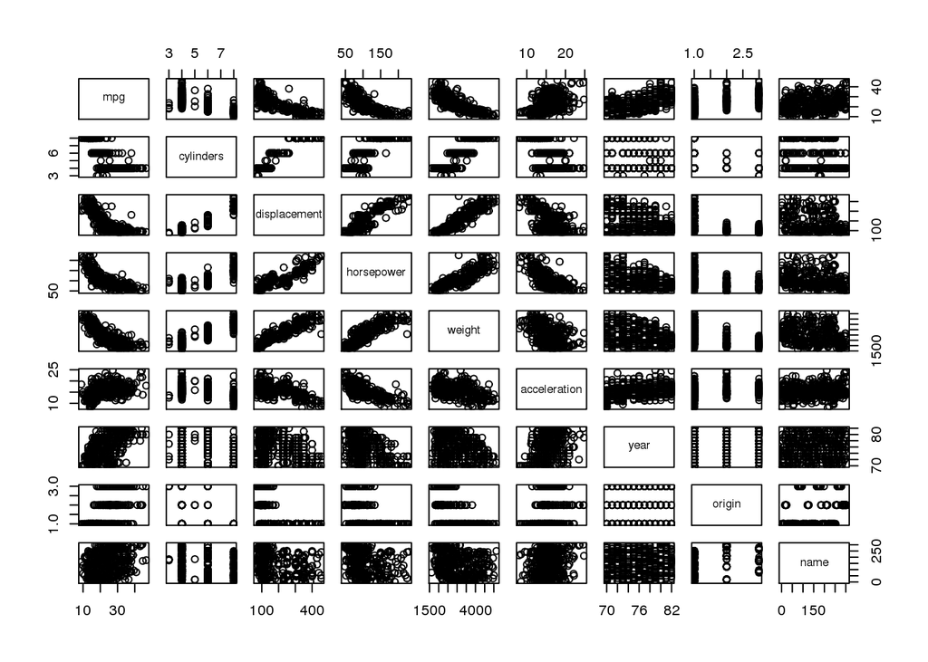

```r
pairs(Auto)
```

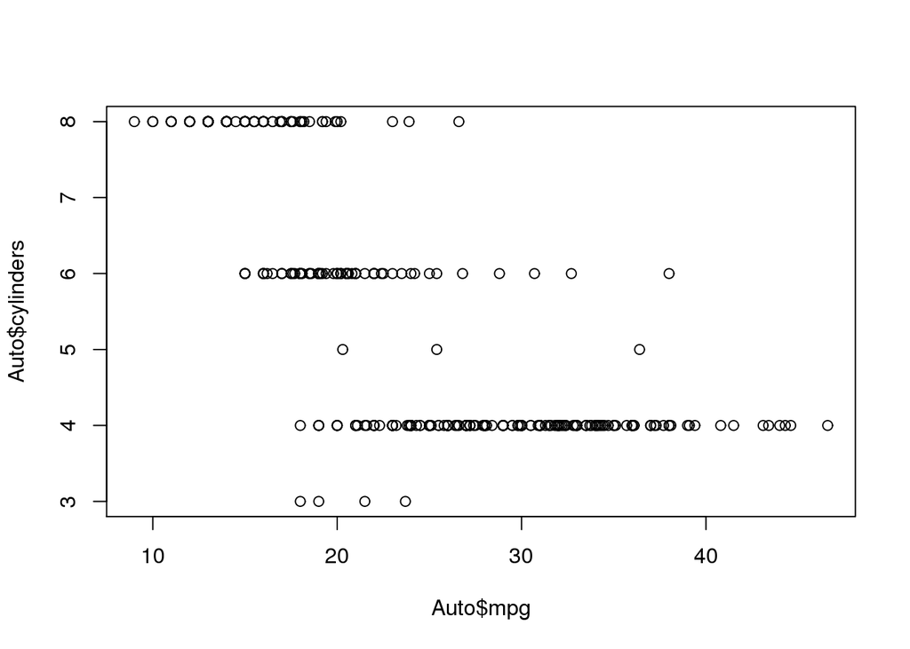

```r
plot(Auto$mpg, Auto$cylinders)
```

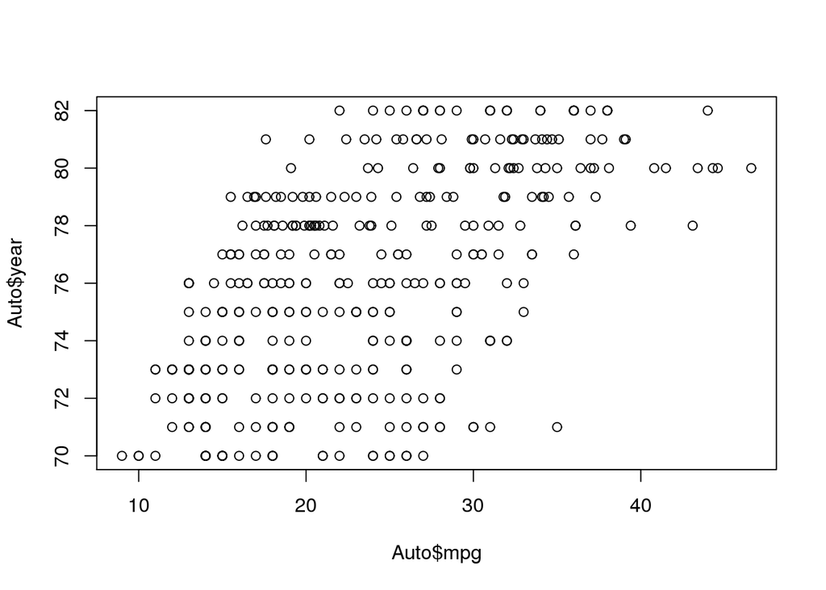

```r
#We see that with lower cylinders cars, you get a higher mpg value.
plot(Auto$mpg, Auto$year)
```

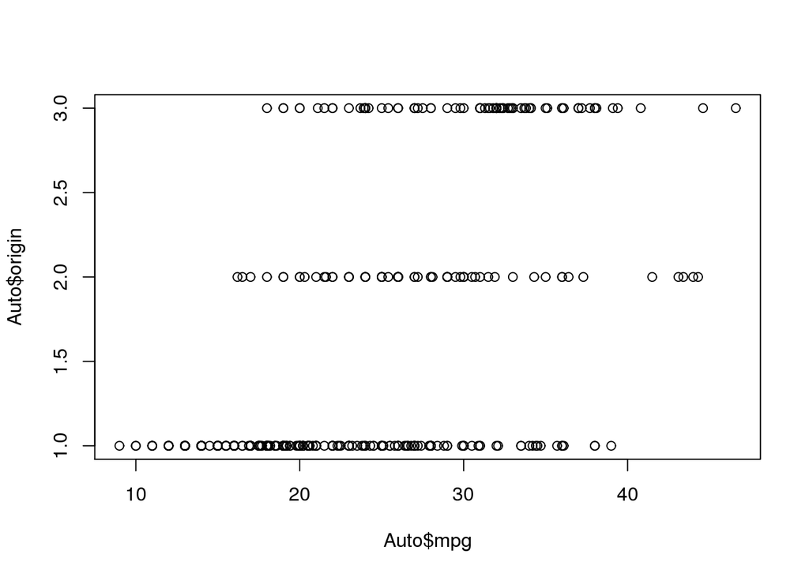

```r
#We also see a weak trend that cars that are older have a lower mpg value than cars that are newer.
plot(Auto$mpg, Auto$origin)
```

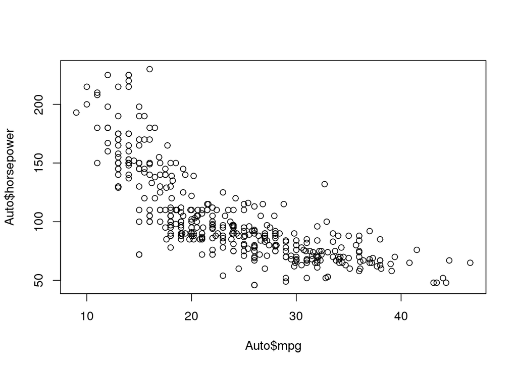

```r
#Japanese cars tend to get better mpg than European or American cars.
plot(Auto$mpg, Auto$horsepower)
```

```r
#The stronger the engine, the lower mpg it gets.
```

Based on the plots in the previous question, I believe that cylinders, year, origin, and horsepower could be use as predictors for mpg because for horsepower, it seems to have an inverse relationship with mpg. As for year, we see a positive trend that as the year increases, so does mpg. For origin, it shows that Japanese cars tend to have a better mpg value than European or American cars. For cylinders, it also has a somewhat inverse relationship where the lower cylinders provide a better mpg value.